[figure not shown]

# Real World Linear Regression

#### Business Problem

Over the course of several years, a SaaS startup has managed to build an impressive portfolio of customers who are using the product for compliance reporting in the Healthcare space. Over the long time period of building the product, bringing it to market and determining its peceived value to customers, the organization ‘sold’ the product at a variety of price points based on a variety of factors. (i.e. favorable pricing to blue chip names, discounted pricing to stay afloat in lean times, etc.)

After achieving 100+ customers, the organization wanted to begin a user based license pricing model.

#### Goal

Before setting a price per user, the organization wanted to determine how MRR is currently positioned when evaluated by number of users and determine if this was the correct starting point for determining a per user monthly license.

#### Tools

**R-Studio** with *tidyverse library*

##### Steps

*1. Import Excel speadsheet with the following fields:*

- Account Name (string)
- Users (numeric)
- Monthly Recurring Revenue (numeric)
- Billing State (factor)
- Industry (factor)

```
## tibble [114 × 5] (S3: tbl_df/tbl/data.frame)
##  $ Account               : chr [1:114] "Account 2" "Account 3" "Account 4" "Account 5" ...
##  $ Users                 : num [1:114] 1 22 14 6 5 9 58 45 10 2 ...
##  $ MRR                   : num [1:114] 585 9224 1379 2437 3290 ...
##  $ Billing State/Province: chr [1:114] "New York" "West Virginia" "Tennessee" "Kansas" ...
##  $ Industry              : chr [1:114] "Independent Specialty Pharmacy" "Health System" "Independent Specialty Pharmacy" "Independent Specialty Pharmacy" ...
```

*2. Build a Linear Model and fit a regression line to the data for Users to predict MRR (Monthly Recurring Revenue)*

```r
mod <- lm(MRR ~ Users)
```

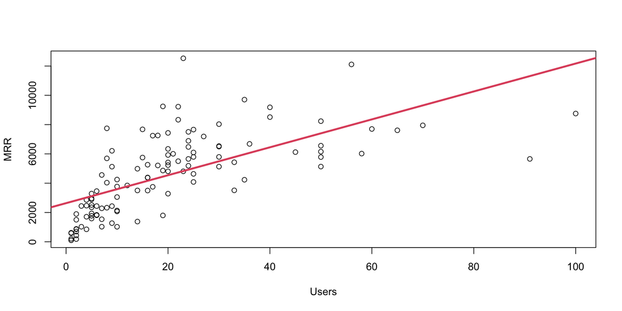

```r
mod$coefficients
```

```
## (Intercept)       Users
##   2637.3276     95.3888
```

*3. Determine the slope for ‘User’ in the model to understand how additional single users impact MRR*

We can see the estimate of slope for Users is 95.39 - meaning that based on this model for every additional user (past the Y intercept), the additional MRR is roughly $95.39.

*4. Predict MRR based on a specific number of users*

```r
predict(mod, list(Users=30))
```

```
##        1
## 5498.992
```

> $5498.99 per month for 30 Users

```r
predict(mod, list(Users=45))
```

```
##        1
## 6929.824
```

> $6929.82 per month for 45 Users

Go Back